# Interpreting random forest

Since there is no inherent structure in a random forest, it is not immediately explainable. We are, however, interested in getting some idea about the overall impact of different features on the claim amount. For this reason we focus on making partial dependence plots.

## Local explanations (shapley)

The following plots show the shapley values for the 6 observations of interest. It reflect that higher exposure generally gives higher claim amount since it generally has a positive effect when above 0.5 and negative below. Marriage status and gender typically go under “all other factors”, meaning they do not have a big impact compared to the features related to the car and the insurance.

### Observation 1386

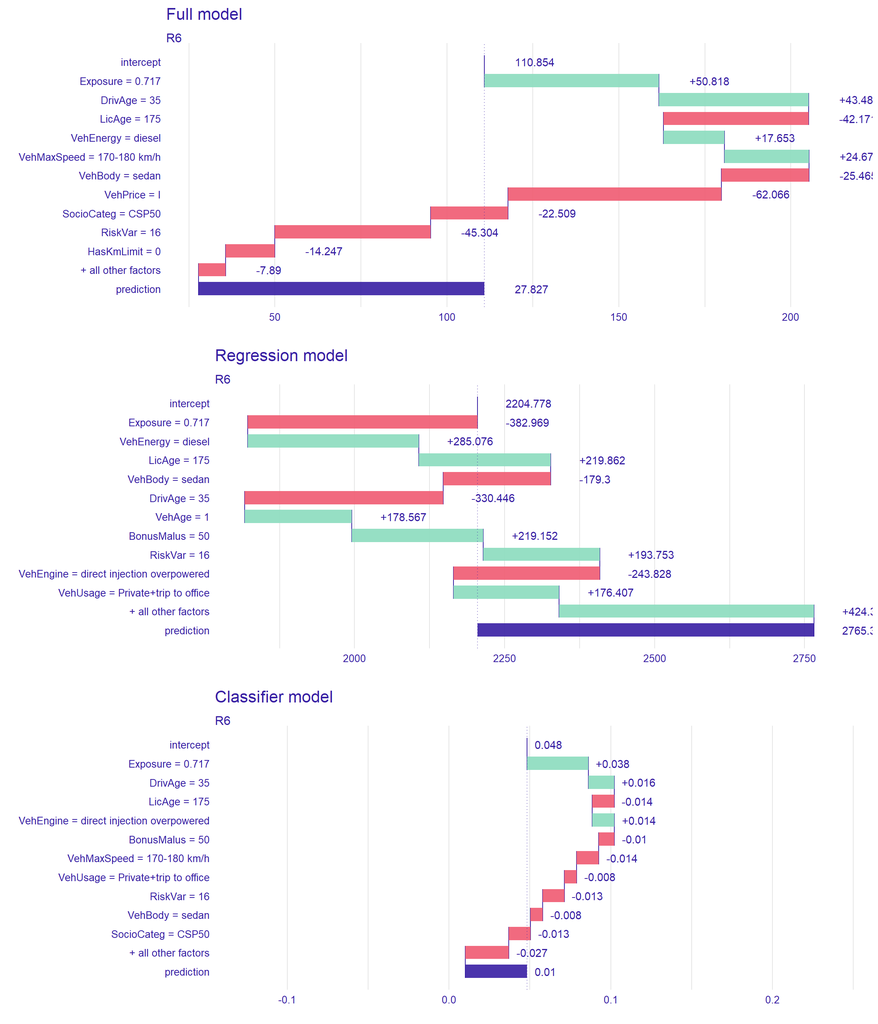

### Observation 12286

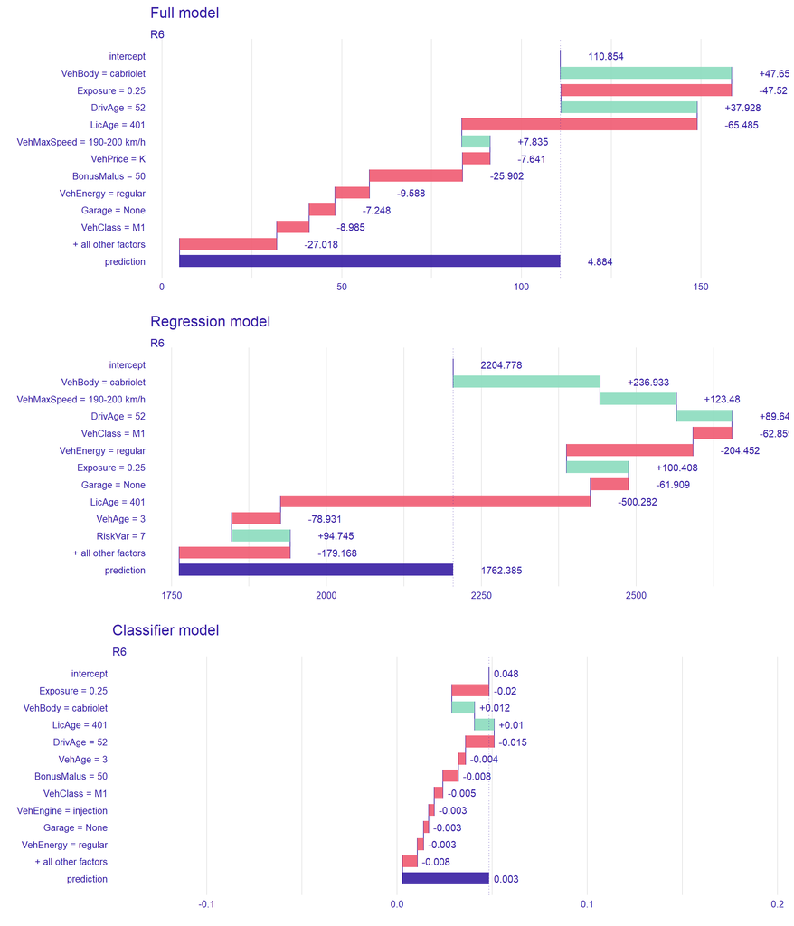

### Observation 2119

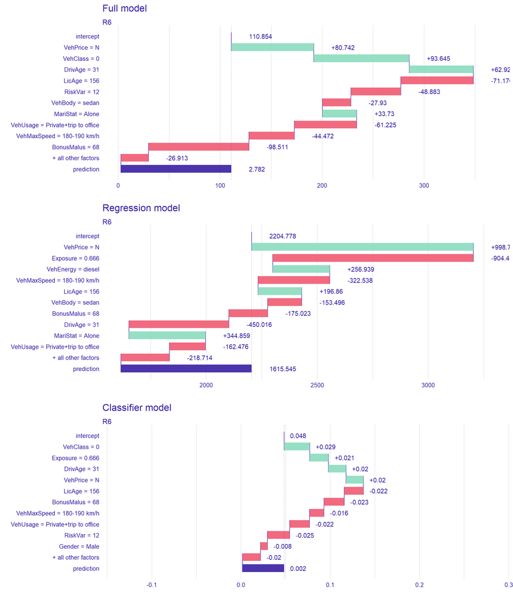

### Observation 2238

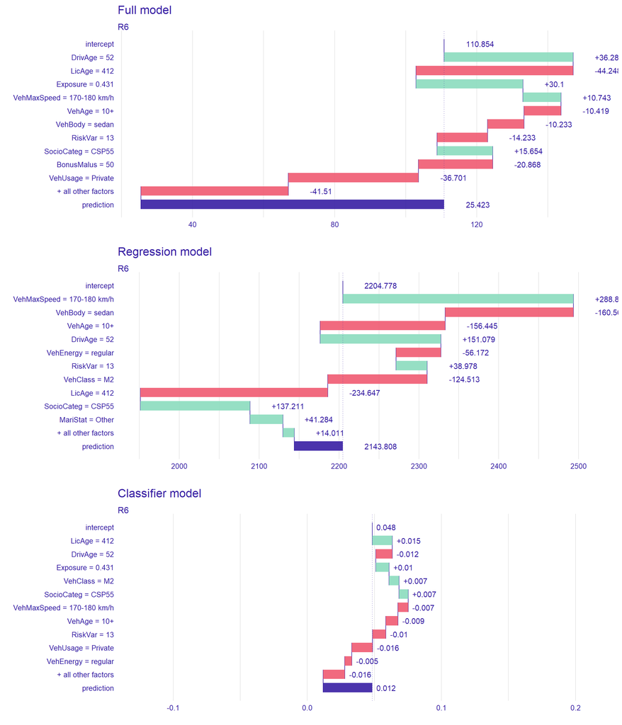

### Observation 27833

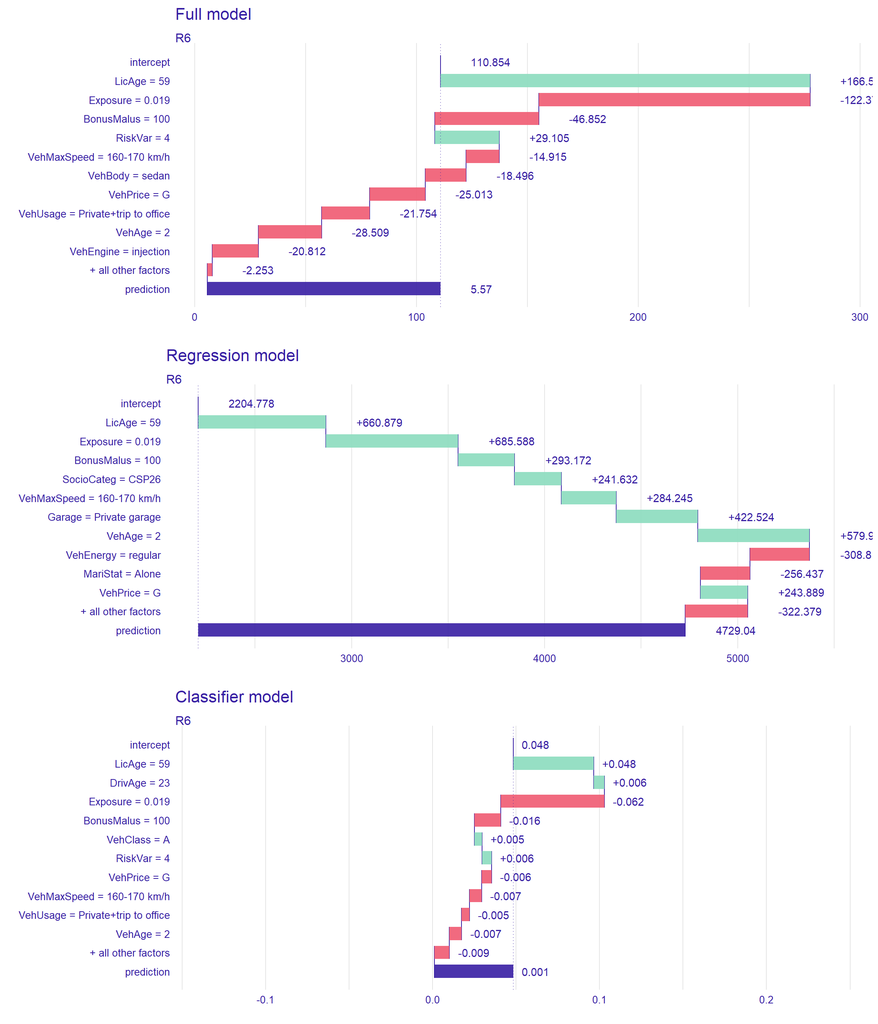

### Observation 27988

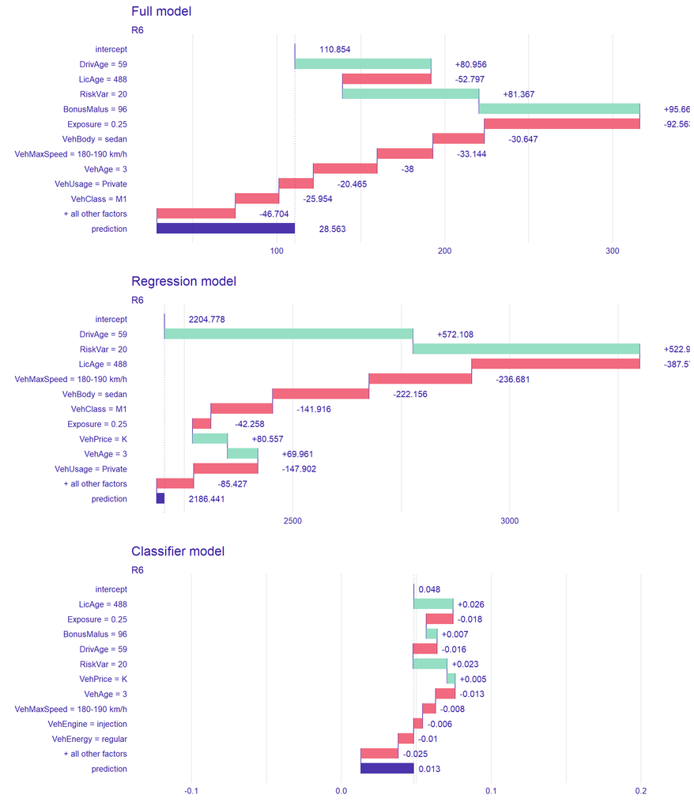

##

## Global explanations

### Partial dependence plots

We make pdps for continuous variables. This is not really sensible for unordered variables such as Gender and Maristat, and categorical variables like max speed (since this is defined by intervals). The variables Gender and MariStat can be seen in the next section using averages and standard errors.

#### full model

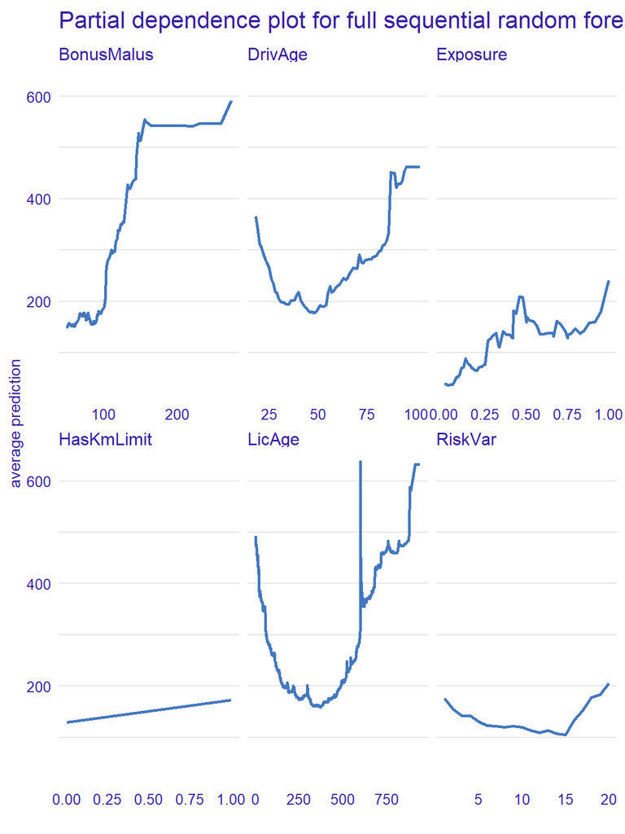

#### classifier

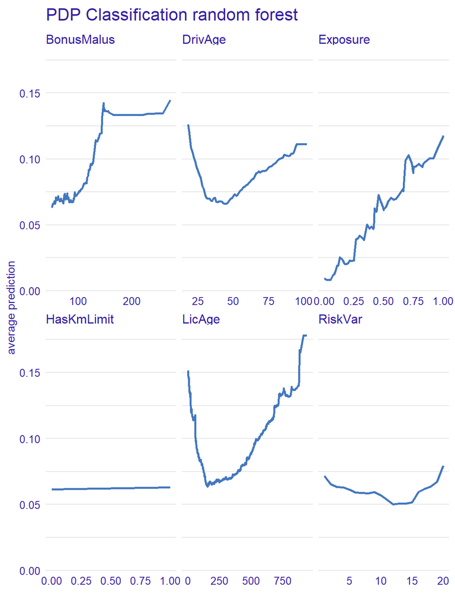

#### regression

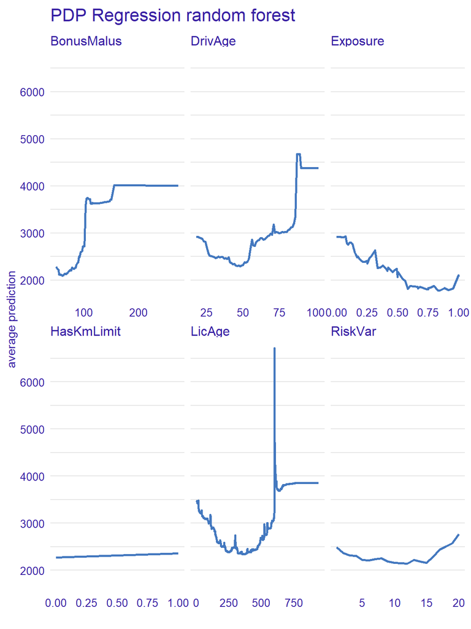

**BonusMalus:**

We can see that BonusMalus generally has a positive effect, but it plateus around 150 with a small spike for the biggest values. This is spike seems to arise from the classification model.

**DrivAge:**

All of the models agree that young people have higher claim amounts while more experienced drivers lead to lower claim amounts. Once the experienced drivers become older they seem to make higher claim amounts as well, possibly because they get worse eyesight and reaction times.

**Exposure:**

**HasKmLimit**

There is a slight increase for cars with a km limit. Note this variable is actually categorical

**LicAge:**

There is a strange peak around license age of 600, but otherwise this feature is highly correlated with dirver age and as such shows much the same picture

**Riskvar**

### Average response based on gender and mariage status

#### Gender

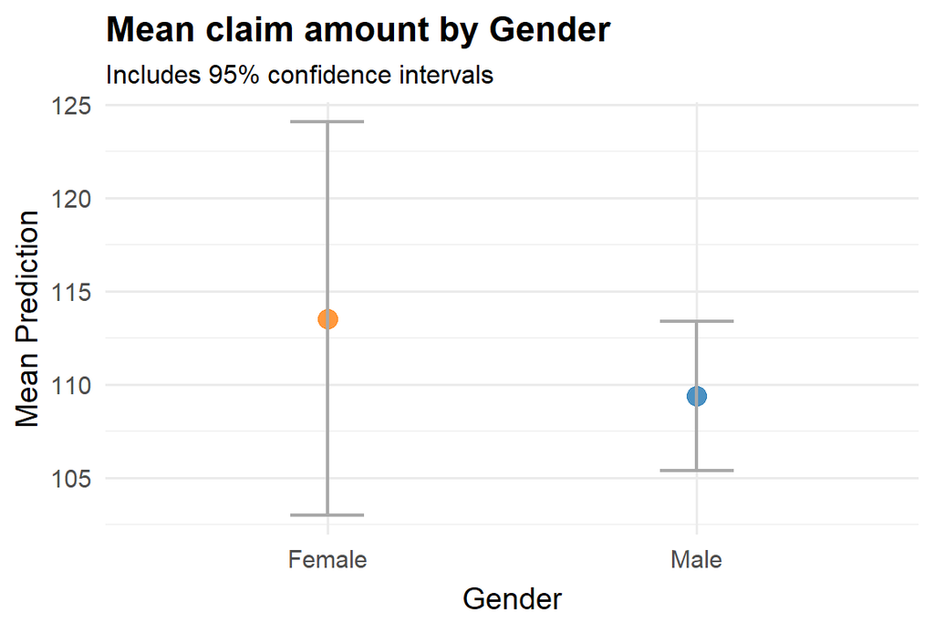

#### Marriage Status

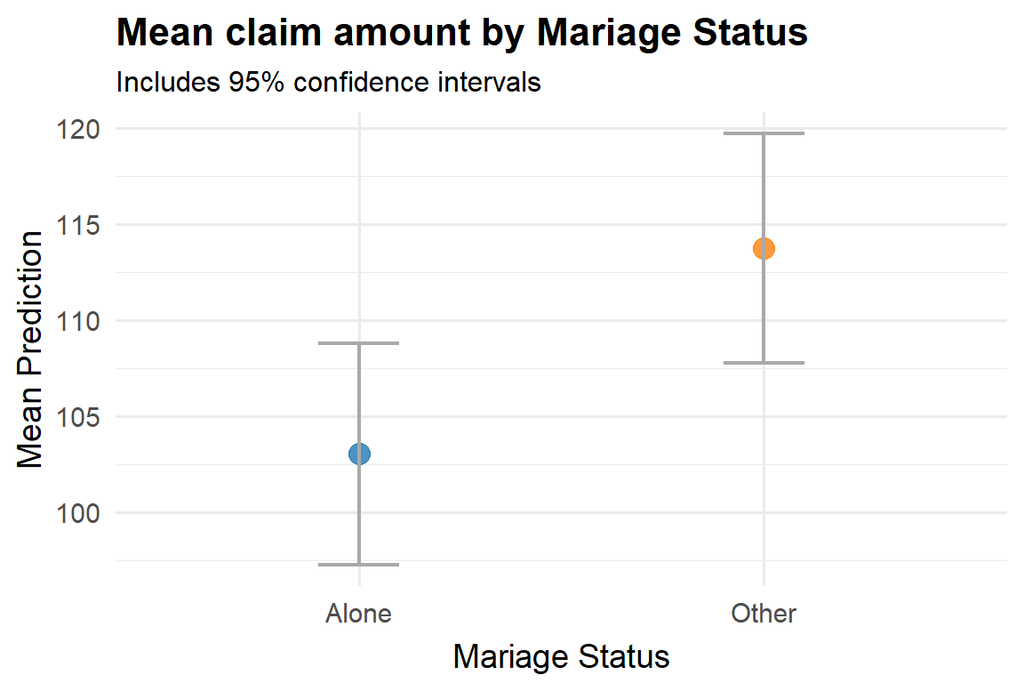

#### Gender:MarriageStatus

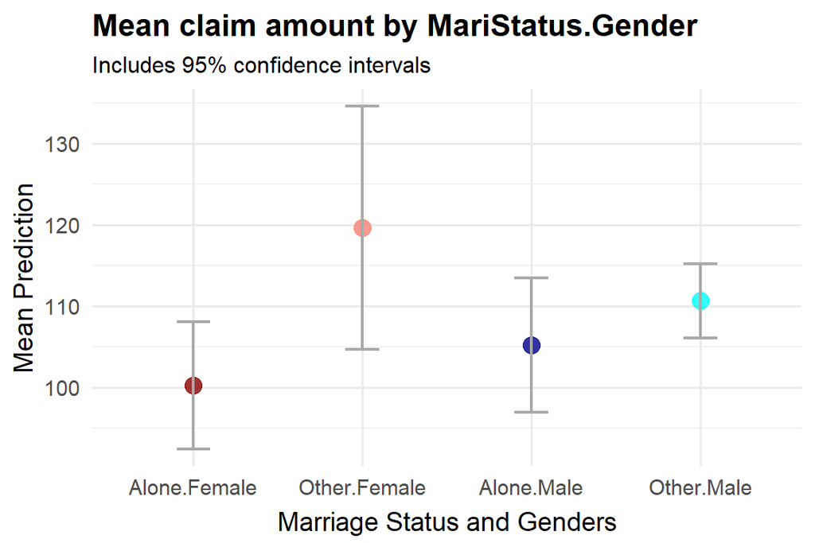